# thermal_analysis

### Using probabilistic modelling to reconstruct a building's thermal model with minimal sensor deployments

#### The goal

We want to derive a simple method for identifying the underlying thermal behaviour model of a room/building. If our ambition is to develop a market-viable solution, it is necessary that this method entails a low cost of deployment. One way to achieve this is by making sure that thermal modelling can be accomplished with minimal requirements for sensor installations.

#### The resistor-capacitor (RC) modelling approach -- The $Ti$ model

The simplest configuration to model the heat dynamics of a room/building is the $Ti$ model, which is illustrated by the RC-network below:

[figure not shown]

The model has one state variable $T_i$, which is the temperature of the interior ($^{\circ}C$), and the following parameters:

- $C_i$: The heat capacity of the entire room/building ($kWh/ ^{\circ}C$)
- $\Phi_h$: The energy flux from the heating system ($kW$)
- $A_w$: The effective window area of the room/building ($m^2$)
- $\Phi_s$: The energy flux from solar radiation ($kW$)
- $R_{ia}$: The thermal resistance from the interior to the ambient ($^{\circ}C/kW$)
- $T_a$: The ambient air temperature ($^{\circ}C$)

The thermal resistance $R_{ia}$ can be regarded as the result of two resistance components placed in parallel; the resistor used for modelling the thermal resistance of the walls and the resistor used for modelling air infiltration (e.g. from windows):

$R_{ia} = \dfrac{1}{U_i\cdot{A_i} + Vol_i\cdot{ach}}$

where:

- $U_i$: The U-value of the room/building, i.e. the outward steady-state heat flow per degree of temperature difference across the wall ($kW/{m^{2}}^{\circ}C$)
- $A_i$: The wall area of the room/building ($m^2$)
- $Vol_i$: The indoor volume of the room/building ($m^3$)
- $ach$: The infiltration rate (air changes per hour)

The stochastic differential equation describing the heat ﬂow is:

$\dfrac{dT_i}{dt} = \dfrac{1}{R_{ia}\cdot{C_i}}\cdot{(T_a - T_i)} + \dfrac{1}{C_i}\cdot{A_w} \cdot{\Phi_s} + \dfrac{1}{C_i}\cdot{\Phi_h} + \sigma_i\cdot{\dfrac{dW}{dt}}$

where:

- $\sigma_i$: The standard deviation of the noise for the indoor temeprature process
- $W$: A standard Wiener process, $W_{t+\Delta{t}} - W_{t}\sim{N(0, \sqrt{\Delta{t}})}$

The measurement equation is:

$y_k = T_{i,k} + e_k$

where:

- $e_k$: The measurement error, $e_k \ i.i.d. \sim{N(0, \sigma^2)}$

#### The dataset

The data used here was collected during a series of experiments carried out in February to April 2009 in FlexHouse. FlexHouse is an office building located at Risø DTU, the National Laboratory for Sustainable Energy. The data is thoroughly described in [Experiments and data for building energy performance analysis](http://orbit.dtu.dk/en/publications/experiments-and-data-for-building-energy-performance-analysis%28100c2e3b-8bb2-4a83-bab3-ae769708cec8%29.html) (P. Bacher and H. Madsen, Technical report, DTU Informatics, 2010), and it can be found [here](http://ctsm.info/) (Building 2).

The corresponding time series consists of five-minute averaged values of:

- An single signal representing the indoor temperature, formed as the first principal component of measurements from heat sensors hanging freely in the middle of each room in the building ($^{\circ}C$).
- The total heat input for all electrical heaters in the building ($kW$). The controlled heat input is a pseudo-random binary sequence (PRBS), which has white noise properties and no correlation with other inputs. It is applied in order to optimize the information embedded in data {see Henrik Madsen and J.M. Schultz. [Short time determination of the heat dynamics of buildings](http://www.byg.dtu.dk/~/media/Institutter/Byg/publikationer/lfv/lfv_243.ashx?la=da). Technical report, DTU, 1993).
- The observed ambient temperature from a climate station located 2 meters from the building ($^{\circ}C$).
- The solar irradiance measured at the climate station ($kW/m^2$).

```python
%matplotlib inline
```

```python
import datetime
import pandas as pd
import numpy as np
import statsmodels.api as sm
from numba import jit
import pymc

import matplotlib.pyplot as plt
from matplotlib import mlab
plt.rcParams['figure.dpi'] = 300
plt.rcParams['savefig.dpi'] = 300

import seaborn as sns
sns.set(context='paper')
```

```python
dataset = pd.read_csv("data/inputPRBS1.csv", sep=';')
dataset['t'] = dataset['t'].map(lambda x: datetime.datetime(2009, 2, 5, 14, 26) + datetime.timedelta(0, x * 3600))
dataset.set_index(['t'], inplace=True)
```

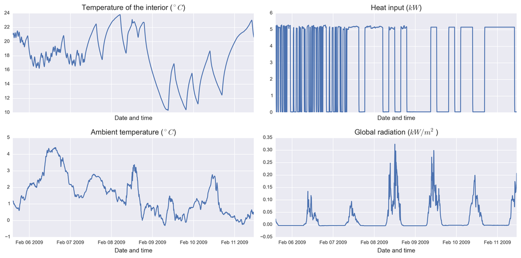

```python
fig, axes = plt.subplots(nrows=2, ncols=2, sharex=True, squeeze=True, figsize=(12, 6))
axis_font = {'size':'10'}

plots = {}
plots['yTi'] = 'Temperature of the interior ($^{\circ}C$)'
plots['Ta'] = 'Ambient temperature ($^{\circ}C$)'
plots['Ph'] = 'Heat input ($kW$)'
plots['Ps'] = 'Global radiation ($kW/m^2$)'

for ax, key in zip(np.ravel(axes), ['yTi', 'Ph', 'Ta', 'Ps']):
    ax.plot(dataset.index, dataset[key])
    ax.set_title(plots[key], size=12)
    ax.set_xlabel('Date and time', **axis_font)

fig.tight_layout();
```

#### Gray-box modelling: Plugging a probabilistic model in a stochastic system dynamics model

A data-driven approach for identifying the parameters of a RC-model can be developed using probabilistic programming; given a grey-box model, estimates of the parameters can be obtained.

First, define stochastic priors for the parameters to identify.

- $R_{ia}$: The thermal resistance from the interior to the ambient
- $C_i$: The heat capacity of the entire building
- $A_w$: The effective window area of the building
- $\sigma_i$: The standard deviation of the noise for the indoor temeprature process

```python
# stochastic priors
Ria = pymc.Uniform('Ria', lower=1e-5, upper=50.)
Ci = pymc.Uniform('Ci', lower=1e-5, upper=100.)
Aw = pymc.Uniform('Aw', lower=0.1, upper=200)
tau = pymc.Normal('tau', mu=.01, tau=100., value=.01)
```

Discretize the stochastic dynamic model.

```python
@jit(nopython=True)
def _Ti_path(Ti, Ta, Ps, Ph, Ria, Ci, Aw):
    N = len(Ti)
    Ti_infer = np.empty(N)
    Ti_infer[0] = Ti[0]

    for i in range(N-1):
        Ti_infer[i+1] = Ti[i] + (Ta[i]-Ti[i]) / (Ria*Ci) + (Ph[i] + Aw*Ps[i]) / Ci

    return Ti_infer[1:]
```

Define the data generating process.

```python
Ti = dataset['yTi'].values
Ta = dataset['Ta'].values
Ps = dataset['Ps'].values
Ph = dataset['Ph'].values

@pymc.deterministic
def Ti_path(Ria=Ria, Ci=Ci, Aw=Aw):
    return _Ti_path(Ti, Ta, Ps, Ph, Ria, Ci, Aw)
```

Define a data likelihood function.

```python
target = dataset['yTi'].values[1:]

temperature = pymc.Normal('obs', mu=Ti_path, tau=tau, value=target, observed=True)
```

Package the full model in a dictionary.

```python
model = dict(Ria=Ria, Ci=Ci, Aw=Aw, tau=tau, Ti_path=Ti_path, temperature=temperature)
```

Fit the model with MCMC.

```python
map_ = pymc.MAP(model)
map_.fit()
mcmc = pymc.MCMC(model)
mcmc.use_step_method(pymc.AdaptiveMetropolis, [model[i] for i in ['Ria', 'Ci', 'Aw']])
mcmc.sample(iter=700000, burn=100000, thin=60, verbose=0)
```

```
 [-----------------100%-----------------] 700000 of 700000 complete in 882.4 sec
```

Plot the posterior distributions of the parameters that define the building's thermal behaviour.

```python
plots = {}
plots['Ria'] = '\n\nThermal resistance from the interior to the ambient'
plots['Ci'] = 'Thermal capacity of the entire building'
plots['Aw'] = 'Effective window area of the building'
plots['Rih'] = 'Thermal resistance from the heater to the interior'
plots['Ch'] = 'Thermal capacity of the heating system'
```

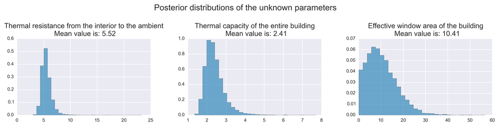

```python
fig, axes = plt.subplots(nrows=1, ncols=3, squeeze=True, figsize=(12, 3))

for ax, key in zip(np.ravel(axes), ['Ria', 'Ci', 'Aw']):
    if(key == 'Ci'): # scale to kWh/C
        ax.hist(model[key].trace()*5./60, histtype='stepfilled', bins=30, alpha=0.7, color='#348ABD', normed=True)
        ax.set_title('%s\n Mean value is: %0.2f' %(plots[key], model[key].stats()['mean']*5./60), size=12)
    else:
        ax.hist(model[key].trace(), histtype='stepfilled', bins=30, alpha=0.7, color='#348ABD', normed=True)
        ax.set_title('%s\n Mean value is: %0.2f' %(plots[key], model[key].stats()['mean']), size=12)

fig.suptitle('Posterior distributions of the unknown parameters', fontsize=14)
fig.tight_layout();
```

Has the MCMC chain run for long enough? Plot the autocorrelation of the MCMC samples.

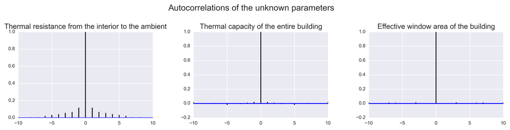

```python
fig, axes = plt.subplots(nrows=1, ncols=3, squeeze=True, figsize=(12, 3))

for ax, key in zip(np.ravel(axes), ['Ria', 'Ci', 'Aw']):
    ax.acorr(model[key].trace(), detrend = mlab.detrend_mean, usevlines = True)
    ax.set_title(plots[key], size=12)

fig.suptitle('Autocorrelations of the unknown parameters', fontsize=14)
fig.tight_layout();
```

Plot the residuals of the predictive model.

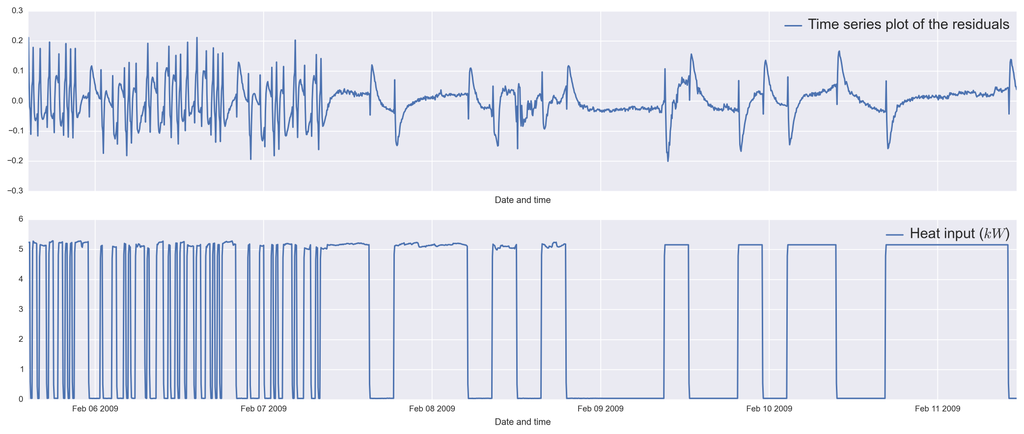

```python
pred = model['Ti_path'].stats()['mean']
resid = pred - target
index = dataset['yTi'].index[1:]

fig, axes = plt.subplots(nrows=2, ncols=1, sharex=True, squeeze=True, figsize=(14, 6))

axes[0].plot(index, resid, label='Time series plot of the residuals')
axes[1].plot(index, Ph[1:], label='Heat input ($kW$)')

for ax in np.ravel(axes):
    ax.set_xlabel('Date and time')
    legend = ax.legend()
    plt.setp(legend.get_texts(), fontsize='14')

    fig.tight_layout();
```

It becomes apparent that the dynamics of the system is poorly modelled right after level shifts in the heat input signal, i.e. every time the heaters are turned on and off.

#### The resistor-capacitor (RC) modelling approach -- The $TiTh$ model

This model is derived by augmenting $Ti$ with an additional state that captures the temperature, thermal resistance and thermal capacity of the heaters:

[figure not shown]

The stochastic differential equations describing the heat ﬂow are:

$\dfrac{dT_i}{dt} = \dfrac{1}{C_i\cdot{R_{ia}}}\cdot{(T_a - T_i)} + \dfrac{1}{C_i\cdot{R_{ih}}}\cdot{(T_h-Ti)} + \dfrac{1}{C_i}\cdot{A_w}\cdot{\Phi_s} + \sigma_i\cdot{\dfrac{dW}{dt}}$

$\dfrac{dT_h}{dt} = \dfrac{1}{C_h\cdot{R_{ih}}}\cdot{(T_i-Th)} + \dfrac{1}{C_h}\cdot{\Phi_h} + \sigma_h\cdot{\dfrac{dW}{dt}}$

$T_h$ represents the temperature of the internal heaters (in $^{\circ}C$). It is a latent variable that is not directly observed, but inferred from the data. The additional parameters in this model are:

- $R_{ih}$: The thermal resistance between the heaters and the indoor air
- $C_h$: The heat capacity of the electrical heaters
- $\sigma_h$: The standard deviation of the noise for the heater temperature process

```python
# stochastic priors
Ria = pymc.Uniform('Ria', lower=1e-5, upper=50.)
Ci = pymc.Uniform('Ci', lower=1e-5, upper=100.)
Aw = pymc.Uniform('Aw', lower=0.1, upper=200)
tau = pymc.Normal('tau', mu=.01, tau=100., value=.01)

Rih = pymc.Uniform('Rih', lower=1e-5, upper=10.)
Ch = pymc.Uniform('Ch', lower=1e-5, upper=10.)
```

```python
@jit(nopython=True)
def _Ti_path(Ti, Ta, Ph, Ps, Ria, Ci, Aw, Rih, Ch):

    N = len(Ti)
    Ti_infer = np.empty(N)
    Th = np.empty(N)
    Ti_infer[0] = Ti[0]
    Th[0] = Ti[0]

    for i in range(N-1):
        Th[i+1] = Th[i] + (Ti[i]-Th[i]) / (Rih*Ch) + Ph[i] / Ch
        Ti_infer[i+1] = Ti[i] + (Ta[i]-Ti[i]) / (Ria*Ci) + (Th[i]-Ti[i]) / (Rih*Ci) + Aw*Ps[i] / Ci

    return Ti_infer[1:]
```

```python
Ti = dataset['yTi'].values
Ta = dataset['Ta'].values
Ps = dataset['Ps'].values
Ph = dataset['Ph'].values

@pymc.deterministic
def Ti_path(Ria=Ria, Ci=Ci, Aw=Aw, Rih=Rih, Ch=Ch):
    return _Ti_path(Ti, Ta, Ph, Ps, Ria, Ci, Aw, Rih, Ch)
```

Define a data likelihood function.

```python
target = dataset['yTi'].values[1:]

temperature = pymc.Normal('obs', mu=Ti_path, tau=tau, value=target, observed=True)
```

Package the full model in a dictionary.

```python
model = dict(Ria=Ria, Ci=Ci, Aw=Aw, Rih=Rih, Ch=Ch, tau=tau, Ti_path=Ti_path, temperature=temperature)
```

Fit the model with MCMC.

```python
map_ = pymc.MAP(model)
map_.fit()
mcmc = pymc.MCMC(model)
mcmc.use_step_method(pymc.AdaptiveMetropolis, [model[i] for i in ['Ria', 'Ci', 'Aw', 'Rih', 'Ch']])
mcmc.sample(iter=700000, burn=100000, thin=60, verbose=0)
```

```
 [-----------------100%-----------------] 700000 of 700000 complete in 905.7 sec
```

Plot the posterior distributions of the parameters that define the building's thermal behaviour.

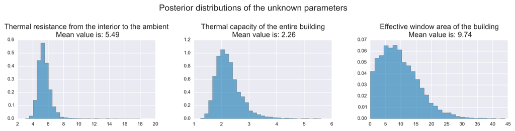

```python
fig, axes = plt.subplots(nrows=1, ncols=3, squeeze=True, figsize=(12, 3))

for ax, key in zip(np.ravel(axes), ['Ria', 'Ci', 'Aw']):
    if(key == 'Ci'): # scale to kWh/C
        ax.hist(model[key].trace()*5./60, histtype='stepfilled', bins=30, alpha=0.7, color='#348ABD', normed=True)
        ax.set_title('%s\n Mean value is: %0.2f' %(plots[key], model[key].stats()['mean']*5./60), size=12)
    else:
        ax.hist(model[key].trace(), histtype='stepfilled', bins=30, alpha=0.7, color='#348ABD', normed=True)
        ax.set_title('%s\n Mean value is: %0.2f' %(plots[key], model[key].stats()['mean']), size=12)

fig.suptitle('Posterior distributions of the unknown parameters', fontsize=14)
fig.tight_layout();
```

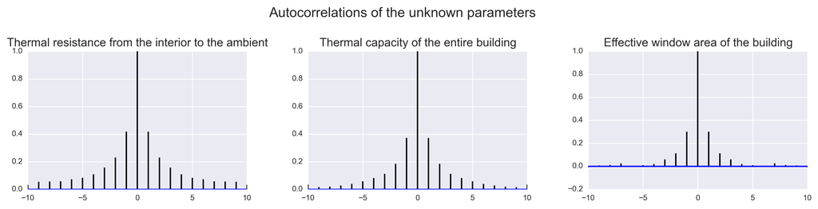

```python
fig, axes = plt.subplots(nrows=1, ncols=3, squeeze=True, figsize=(12, 3))

for ax, key in zip(np.ravel(axes), ['Ria', 'Ci', 'Aw']):
    ax.acorr(model[key].trace(), detrend = mlab.detrend_mean, usevlines = True)
    ax.set_title(plots[key], size=12)

fig.suptitle('Autocorrelations of the unknown parameters', fontsize=14)
fig.tight_layout();
```

Plot the residuals of the predictive model.

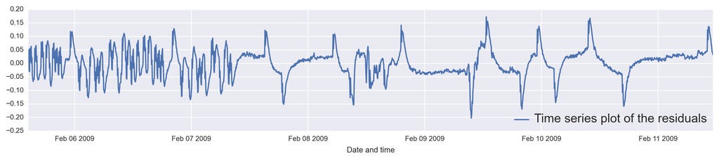

```python
pred = model['Ti_path'].stats()['mean']
resid = pred - target
index = dataset['yTi'].index[1:]

fig, ax = plt.subplots(figsize=(14, 2.5))

ax.plot(index, resid, label='Time series plot of the residuals')
ax.set_xlabel('Date and time')
legend = ax.legend(loc='lower right')
plt.setp(legend.get_texts(), fontsize='14');
```

If enough data is available, one can find subsets that are both short and highly informative with regard to some parameter estimates. For instance, the speed of convergence between outside temperature and inside temperature when an HVAC system is turned off provides much insight into the performance of a building’s fabric.

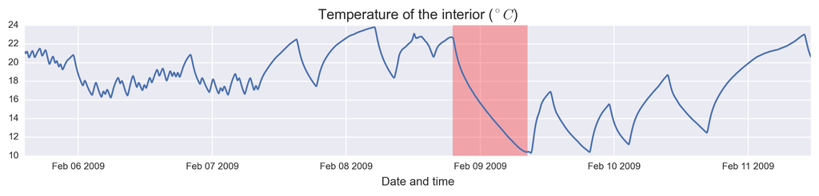

```python
fig, ax = plt.subplots(figsize=(12, 2))
axis_font = {'size':'10'}

ax.plot(dataset.index, dataset['yTi'])
ax.axvspan(datetime.datetime(2009, 2, 8, 19, 6), datetime.datetime(2009, 2, 9, 8, 26), alpha=0.3, color='red')
ax.set_title('Temperature of the interior ($^{\circ}C$)', size=12)
ax.set_xlabel('Date and time', **axis_font);
```

During the marked period in the plot above, both the energy from the heater and the energy from solar radiation is zero. So, the stochastic differential equations describing the heat ﬂow are:

$\dfrac{dT_i}{dt} = \dfrac{1}{C_i\cdot{R_{ia}}}\cdot{(T_a - T_i)} + \dfrac{1}{C_i\cdot{R_{ih}}}\cdot{(T_h-Ti)} + \sigma_i\cdot{\dfrac{dW}{dt}}$

$\dfrac{dT_h}{dt} = \dfrac{1}{C_h\cdot{R_{ih}}}\cdot{(T_i-Th)} + \sigma_h\cdot{\dfrac{dW}{dt}}$

```python
# stochastic priors
Ria_x_Ci = pymc.Uniform('Ria_x_Ci', lower=1e-5, upper=50.)
Rih_x_Ci = pymc.Uniform('Rih_x_Ci', lower=1e-5, upper=50.)
Rih_x_Ch = pymc.Uniform('Rih_x_Ch', lower=1e-5, upper=50.)

tau = pymc.Normal('tau', mu=.01, tau=100., value=.01)
```

```python
@jit(nopython=True)
def _Ti_path(Ti, Ta, Ria_x_Ci, Rih_x_Ci, Rih_x_Ch):

    N = len(Ti)
    Ti_infer = np.empty(N)
    Th = np.empty(N)
    Ti_infer[0] = Ti[0]
    Th[0] = Ti[0]

    for i in range(N-1):
        Th[i+1] = Th[i] + (Ti[i]-Th[i]) / Rih_x_Ch
        Ti_infer[i+1] = Ti[i] + (Ta[i]-Ti[i]) / Ria_x_Ci + (Th[i]-Ti[i]) / Rih_x_Ci

    return Ti_infer[1:]
```

```python
Ti = dataset['yTi'].values
Ta = dataset['Ta'].values

@pymc.deterministic
def Ti_path(Ria_x_Ci=Ria_x_Ci, Rih_x_Ci=Rih_x_Ci, Rih_x_Ch=Rih_x_Ch):
    return _Ti_path(Ti, Ta, Ria_x_Ci, Rih_x_Ci, Rih_x_Ch)
```

```python
target = dataset['yTi'].values[1:]

temperature = pymc.Normal('obs', mu=Ti_path, tau=tau, value=target, observed=True)
```

```python
model = dict(Ria_x_Ci=Ria_x_Ci, Rih_x_Ci=Rih_x_Ci, Rih_x_Ch=Rih_x_Ch,
                                      tau=tau, Ti_path=Ti_path, temperature=temperature)
map_ = pymc.MAP(model)
map_.fit()
mcmc = pymc.MCMC(model)
mcmc.use_step_method(pymc.AdaptiveMetropolis, [model[i] for i in ['Ria_x_Ci', 'Rih_x_Ci', 'Rih_x_Ch']])
mcmc.sample(iter=700000, burn=100000, thin=60, verbose=0)
```

```
 [-----------------100%-----------------] 700000 of 700000 complete in 690.5 sec
```

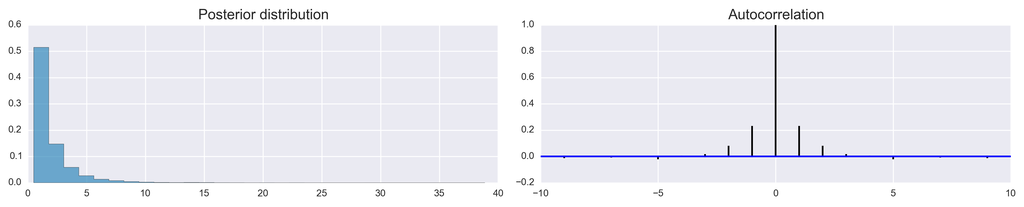

```python
fig, axes = plt.subplots(nrows=1, ncols=2, squeeze=True, figsize=(12, 2.5))

axes[0].hist(model['Rih_x_Ch'].trace(), histtype='stepfilled', bins=30, alpha=0.7, color='#348ABD', normed=True)
axes[0].set_title('Posterior distribution', size=12)

axes[1].acorr(model['Rih_x_Ch'].trace(), detrend = mlab.detrend_mean, usevlines = True)
axes[1].set_title('Autocorrelation', size=12)

fig.tight_layout();
```

```python
from IPython.core.display import HTML


def css_styling():
    styles = open("styles/custom.css", "r").read()
    return HTML(styles)

css_styling()
```

```python
import warnings

warnings.filterwarnings("ignore",category=FutureWarning)
```